# Excel vs R

フードデータ分析基礎演習Ⅱ

佐藤 秀保

sato0035@toyo.jp

## 授業のねらい

- Excelの基本操作（散布図，回帰分析を体験）
- 同じ手順をRで再現し，Rの再現性の利点を確認
- 短時間で「データから言えること」を見つける

## データ

- Toyonet-ACEから「starbucks.xlsx」をダウンロード
  - 出所は「starbucks.csv」
- 1147行（商品）×15列（特徴）のスタバ商品データ

### データの列

1. product_name

   商品名（Brewed Coffee – Dark Roast, Caffè Latte など）
2. size

   サイズ（short, tall, grande, venti, trenta など）
3. milk

   ミルクの種類（数値コード：0=なし, 1=Nonfat, 2=2%…
4. whip

   ホイップクリームの有無（0=なし, 1=あり）
5. serv_size_m_l

   容量（ml）
6. calories

   カロリー（kcal）
7. total_fat_g

   脂質総量（g）
8. saturated_fat_g

   飽和脂肪酸（g）
9. trans_fat_g

   トランス脂肪酸（g）
10. cholesterol_mg

    コレステロール（mg）
11. sodium_mg

    ナトリウム（mg）
12. total_carbs_g

    炭水化物（g）
13. fiber_g

    食物繊維（g）
14. sugar_g

    砂糖（g）
15. caffeine_mg

    カフェイン（mg）

## Excelパート（前半45min）

### 散布図：砂糖とカロリーの関係

1. **散布図を作成**：sugar_gの列とcaloriesの列を選択し，「挿入」タブから散布図を選択
   - Ctrl（macはcommand）キーを押しながらクリックでとびとびの列を選択可
2. **横軸と縦軸入れ替え**：「グラフのデザイン」タブの「データの選択」で「凡例項目」にある「編集」ボタンを押し，Xの値とYの値を逆に（手打ちでNとF部分をそれぞれ逆に書き換えればOK）
3. **直線を引く**：図の点を右クリックし，「近似曲線の追加」で☑「グラフに数式を表示する」
   - 「塗りつぶしと線」のオプション（バケツをひっくり返したようなアイコン）で「色」を黒，「実線/点線」を直線に
4. **軸ラベルを表示**：「グラフのデザイン」タブの「グラフ要素を追加」で「軸ラベル」の「第１縦軸」「第１横軸」，縦軸はCalories(kcal)，横軸はSugar(g)と入力
5. **グラフタイトル削除**
6. **フォント大きめに**

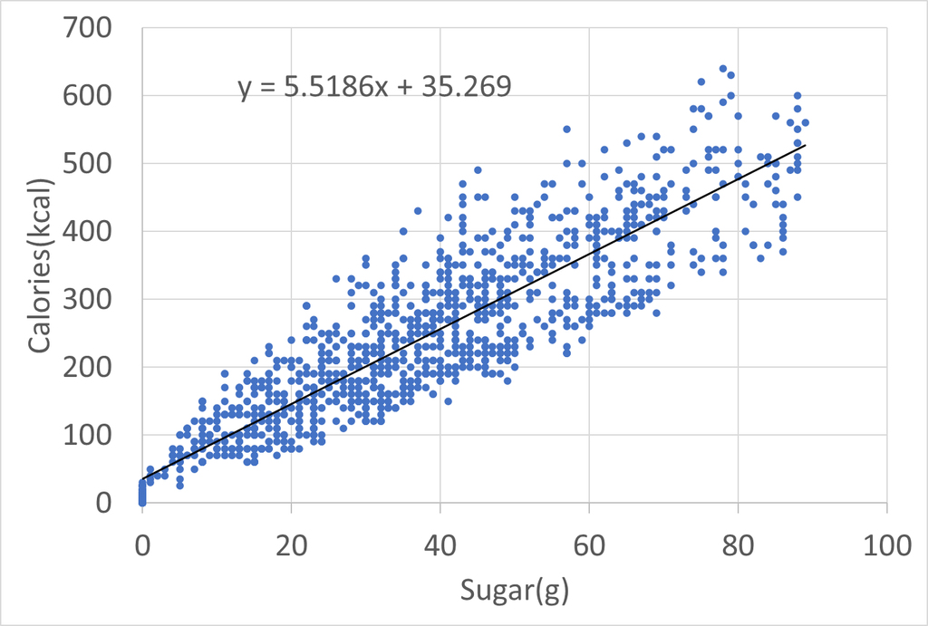

### ディスカッション

- 砂糖とカロリーの平均的な関係性は？
  - 関数型：線形 or 非線形？
  - 符号：正 or 負？
  - 大きさ：砂糖1ｇの増加に対しカロリーは平均的には何kcal増えそう？
- 砂糖とカロリーの関係性のバラツキは？
  - 例えば，同じ40gの砂糖でもカロリーに違いはある？なぜ？

### 回帰分析

- 砂糖以外のカロリーに影響を及ぼす要因（サイズの大小，ミルクの有無，ホイップクリームの有無）を考慮も考慮するために，**重回帰分析**
- データ準備
  1. 左下の〇の中に＋のボタンで「新しいシート」を追加
  2. ５つの列（milk, whip, serv_size_m_l, calories, sugar_g）をコピーし新しいシートに貼り付け
  3. A列を右クリックし，「挿入」後，calories 列を切り取りA列に貼り付け
  4. E列を右クリックし，「削除」
- ツール準備
  1. （エクセルで回帰を一度もやったことのない方は）「ファイル」タブから左下の「オプション」→「アドイン」→下方の「設定」で☑「分析ツール」→OK
  2. 「データ」タブの「データ分析」の「回帰分析」でOK
  3. 「入力Y範囲」でcaloriesの列を，「入力X範囲」でcalories以外のすべての列を選択し，☑「ラベル」，OK
- 係数の部分が「近似曲線」の傾きに該当

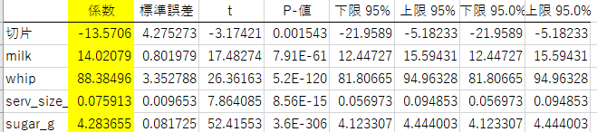

- 結果解釈
  - ミルクが1段階増えると（無し→NonFat→Fat2%…），14kcal増加
  - ホイップが1増えると（ホイップが含まれると），88kcal増加
  - サイズが1ml増えると，0.075kcal増加
  - 砂糖が1g増えると，4.28kcal増加
- 同じ砂糖量でもホイップの有無などでカロリーがバラつくという証拠

## Rパート（後半35min）

### 散布図

1. [**Posit cloudにアクセス**](https://posit.cloud/)**：**New Project→New RStudio Project
2. エクセルは閉じる
3. Filesペインの「Upload」の「ファイルを選択」で「starbucks.xlsx」を「開く」→OK
4. Environmentペインの「Import Dataset」の「from Excel」でYes，を押して待ち，Browseで「starbucks.xlsx」をOpenし「Import」
5. 左上の緑色の〇に白の十字ボタンから「R Script」，スクリプトに以下をコピペし実行
   - Ctrl（macはcommand）キー+Enterを押していけば上から順に実行可能

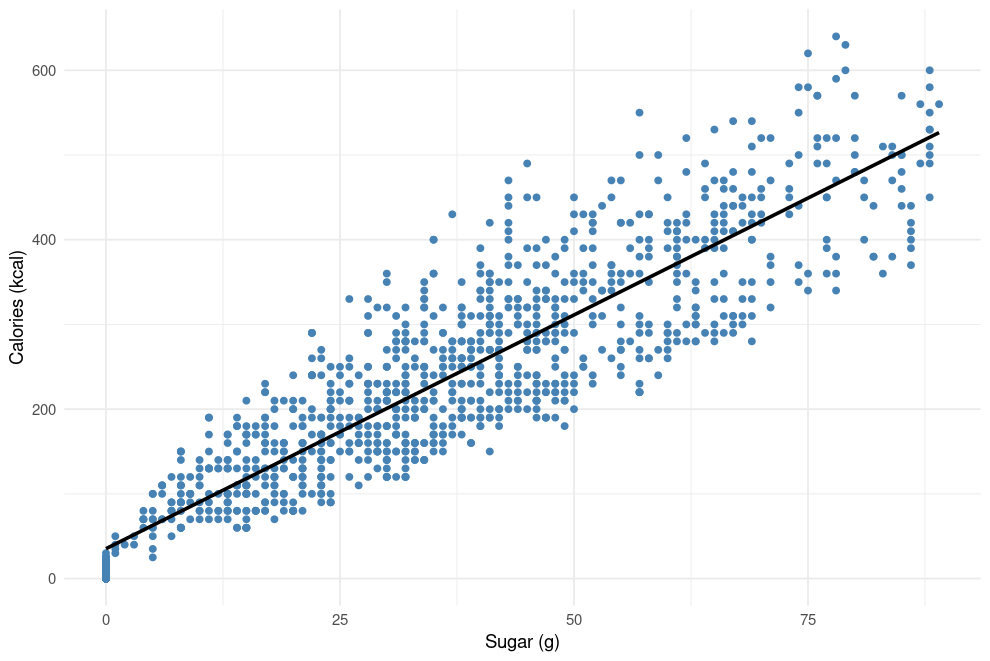

```r
#パッケージ準備
install.packages("tidyverse")
library(tidyverse)

#散布図作成
g1 <- starbucks %>%
  ggplot(aes(x = sugar_g, y = calories)) +
  geom_point(color = "steelblue") +       # 散布図
  geom_smooth(method = "lm", se = FALSE, color = "black") +  # 近似直線
  labs(x = "Sugar (g)", y = "Calories (kcal)") + #軸ラベル
  theme_minimal(base_size = 14) #フォント
g1
```

- メリット
  - コードをコピペしてx,yの指定を変えれば簡単に別の散布図も作成可
    - aesの中のx=とy=の列名を変更
    - g1からg2などに名前を変更
    - labsの中のx=とy=の軸ラベル名を変更

```r
#脂質総量とカロリーの散布図
g2 <- starbucks %>%
  ggplot(aes(x =total_fat_g, y = calories)) +
  geom_point(color = "steelblue") +       # 散布図
  geom_smooth(method = "lm", se = FALSE, color = "black") +  # 近似直線
  labs(x = "Fat (g)", y = "Calories (kcal)") + #軸ラベル
  theme_minimal(base_size = 14) #フォント
g2
```

### 回帰分析

```r
lm(calories ~ milk + whip + serv_size_m_l + sugar_g,
   data = starbucks) %>%
  summary()
```

- 当然同じ結果

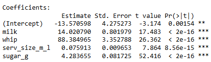

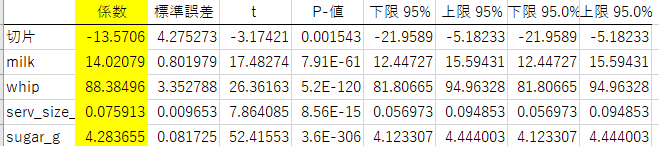

- メリット
  - カロリーに対して様々な要因の影響を回帰分析したが，コード上の変数名を変えればすぐに異なる変数での分析が可能
- １回ではなく，様々な分析をすることで何らかの発見をするので，同じような分析を繰り返すならプログラミング一択！

## 課題：「レポート」２つ

1. 好きな変数２つを選んで，作成した散布図のファイルを提出
   1. Plotsペインの「Export」の「Save as Image」で「Save」
   2. Filesペインの「Rplot.png」に☑して「More」→「Export」→「Download」
   3. PCに保存したそのファイルをACEで提出
2. 好きな変数を選んで，回帰分析し，
   1. その回帰分析のコードをコピペし，
   2. なぜその変数を選んだかを簡単に記し，
   3. 得られた結果は予想と同じか/違うかなどコメント